# CWT fMRI Study - GLMM Analysis Report

Predictive Processing in Emotion Recognition

CWT fMRI Analysis Team

2025-08-06

## Study Overview

This report presents the results of four Generalized Linear Mixed Models (GLMMs) examining predictive processing in emotion recognition using a confidence weighting task.

### Experimental Design

- **Trial Validity:** Valid vs Invalid vs Non-predictive trials
- **Stimulus Noise:** High noise (ambiguous) vs Low noise (clear) faces
- **Learning:** Trials since reversal (learning dynamics)
- **Face Emotion:** Happy vs Angry faces

## Model Results

### 1. Accuracy Model (High Noise Trials Only)

**Research Question:** How does trial validity and learning affect accuracy in high-noise trials?

**Model Specification:**

```
Accuracy ~ TrialValidity2_numeric * TrialsSinceRev_scaled * FaceEmot + (1 | SubNo)
Family: binomial(link = "logit")
Data: High noise trials only
```

Accuracy Model Coefficients

Parameter

Estimate

Std. Error

z-value

p-value

Significance

(Intercept)

(Intercept)

0.9591

0.0411

23.331

2.15e-120

***

TrialValidity2_numeric

TrialValidity2_numeric

0.1400

0.0278

5.027

4.99e-07

***

TrialsSinceRev_scaled

TrialsSinceRev_scaled

-0.0059

0.0250

-0.236

0.81308

FaceEmotHappy

FaceEmotHappy

-0.2458

0.0344

-7.142

9.2e-13

***

TrialValidity2_numeric:TrialsSinceRev_scaled

TrialValidity2_numeric:TrialsSinceRev_scaled

0.0594

0.0273

2.175

0.029615

TrialValidity2_numeric:FaceEmotHappy

TrialValidity2_numeric:FaceEmotHappy

-0.0328

0.0387

-0.847

0.39721

TrialsSinceRev_scaled:FaceEmotHappy

TrialsSinceRev_scaled:FaceEmotHappy

0.0580

0.0350

1.657

0.097536

.

TrialValidity2_numeric:TrialsSinceRev_scaled:FaceEmotHappy

TrialValidity2_numeric:TrialsSinceRev_scaled:FaceEmotHappy

-0.0293

0.0383

-0.765

0.4441

**Key Findings:** - ✅ **Trial Validity:** Valid trials show significantly higher accuracy (z = 5.03, p < 0.001) - ❌ **Face Emotion:** Happy faces show lower accuracy than angry faces (z = -7.14, p < 0.001) - 🔄 **Learning:** Trial validity effects change with learning (interaction: z = 2.18, p = 0.030)

**Interpretation:** Participants are more accurate when cues correctly predict the face emotion, but this effect changes over time as they learn the task contingencies.

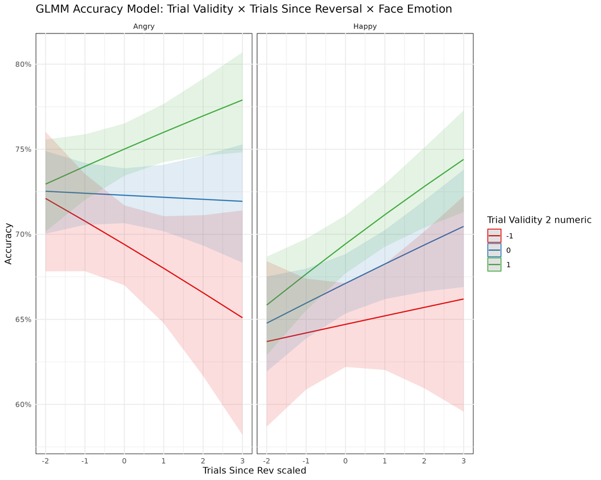

Accuracy Model Predictions: Trial Validity × Trials Since Reversal × Face Emotion

### 2. Choice Model (High Noise Trials Only)

**Research Question:** How do signaled faces and actual emotions influence choice behavior?

**Model Specification:**

```
FaceResponse ~ SignaledFace * FaceEmot * TrialsSinceRev_scaled + (1 | SubNo)
Family: binomial(link = "logit")
Data: High noise trials only
```

Choice Model Coefficients

|  | Parameter | Estimate | Std. Error | z-value | p-value | Significance |
| --- | --- | --- | --- | --- | --- | --- |
| (Intercept) | (Intercept) | -0.9825 | 0.0905 | -10.857 | 1.84e-27 | *** |
| SignaledFaceAngry | SignaledFaceAngry | -0.2770 | 0.0530 | -5.228 | 1.72e-07 | *** |
| FaceEmotHappy | FaceEmotHappy | 1.9465 | 0.0535 | 36.379 | 9.01e-290 | *** |
| TrialsSinceRev_scaled | TrialsSinceRev_scaled | 0.1316 | 0.0456 | 2.888 | 0.0038827 | ** |
| SignaledFaceAngry:FaceEmotHappy | SignaledFaceAngry:FaceEmotHappy | 0.0174 | 0.0731 | 0.238 | 0.81193 |  |
| SignaledFaceAngry:TrialsSinceRev_scaled | SignaledFaceAngry:TrialsSinceRev_scaled | -0.2183 | 0.0533 | -4.096 | 4.21e-05 | *** |
| FaceEmotHappy:TrialsSinceRev_scaled | FaceEmotHappy:TrialsSinceRev_scaled | -0.0274 | 0.0520 | -0.527 | 0.59788 |  |
| SignaledFaceAngry:FaceEmotHappy:TrialsSinceRev_scaled | SignaledFaceAngry:FaceEmotHappy:TrialsSinceRev_scaled | 0.1456 | 0.0743 | 1.960 | 0.050027 | . |

**Interpretation:** Participants use predictive cues to guide their choices, but also respond strongly to the actual face emotion. Learning modulates these effects.

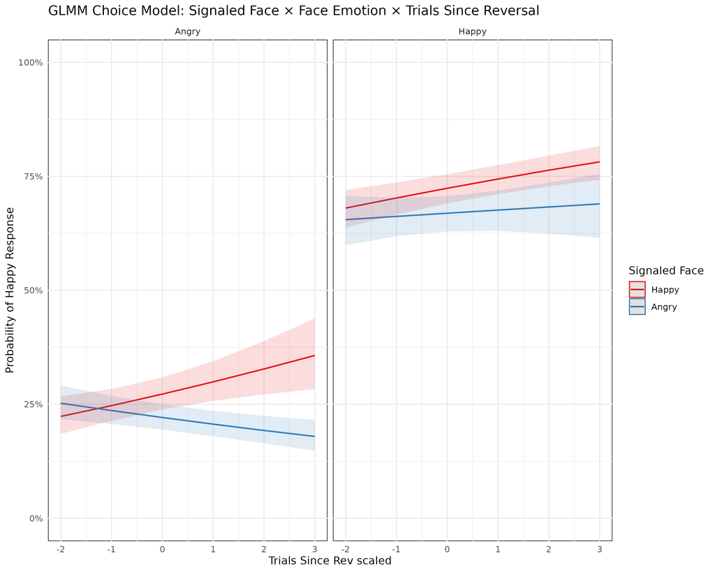

Choice Model Predictions: Signaled Face × Face Emotion × Trials Since Reversal

### 3. Response Time Model (All Trials)

**Research Question:** How do stimulus noise and trial validity affect response times?

**Model Specification:**

```
ResponseRT ~ StimNoise * TrialValidity2_numeric * TrialsSinceRev_scaled + (1 | SubNo)
Family: Gamma(link = "log")
Data: All trials
```

Response Time Model Coefficients

|  | Parameter | Estimate | Std. Error | z-value | p-value | Significance |
| --- | --- | --- | --- | --- | --- | --- |
| (Intercept) | (Intercept) | -0.3987 | 0.0155 | -25.745 | 3.69e-146 | *** |
| StimNoisehigh noise | StimNoisehigh noise | 0.3234 | 0.0046 | 70.345 | 0e+00 | *** |
| TrialValidity2_numeric | TrialValidity2_numeric | -0.0212 | 0.0036 | -5.875 | 4.23e-09 | *** |
| TrialsSinceRev_scaled | TrialsSinceRev_scaled | 0.0063 | 0.0033 | 1.919 | 0.054946 | . |
| StimNoisehigh noise:TrialValidity2_numeric | StimNoisehigh noise:TrialValidity2_numeric | 0.0081 | 0.0051 | 1.584 | 0.11322 |  |
| StimNoisehigh noise:TrialsSinceRev_scaled | StimNoisehigh noise:TrialsSinceRev_scaled | 0.0064 | 0.0047 | 1.369 | 0.1709 |  |
| TrialValidity2_numeric:TrialsSinceRev_scaled | TrialValidity2_numeric:TrialsSinceRev_scaled | -0.0117 | 0.0036 | -3.259 | 0.0011171 | ** |
| StimNoisehigh noise:TrialValidity2_numeric:TrialsSinceRev_scaled | StimNoisehigh noise:TrialValidity2_numeric:TrialsSinceRev_scaled | 0.0014 | 0.0051 | 0.278 | 0.78069 |  |

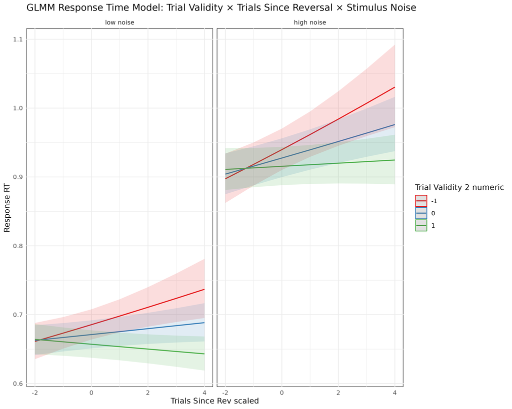

Response Time Model Predictions: Stimulus Noise × Trial Validity × Trials Since Reversal

### 4. Confidence Model (All Trials)

**Research Question:** How do trial validity and stimulus noise affect confidence ratings?

**Model Specification:**

```
RawConfidence ~ TrialValidity2_numeric * StimNoise * TrialsSinceRev_scaled + FaceEmot + (1 | SubNo)
Family: Beta(link = "logit")
Data: All trials
```

Confidence Model Coefficients

Parameter

Estimate

Std. Error

z-value

p-value

Significance

(Intercept)

(Intercept)

1.7431

0.0469

37.162

2.84e-302

***

TrialValidity2_numeric

TrialValidity2_numeric

0.0284

0.0109

2.599

0.0093527

StimNoisehigh noise

StimNoisehigh noise

-1.6377

0.0129

-127.096

0e+00

***

TrialsSinceRev_scaled

TrialsSinceRev_scaled

-0.0216

0.0097

-2.217

0.026643

FaceEmotHappy

FaceEmotHappy

0.1744

0.0095

18.352

3.21e-75

***

TrialValidity2_numeric:StimNoisehigh noise

TrialValidity2_numeric:StimNoisehigh noise

-0.0157

0.0135

-1.161

0.24554

TrialValidity2_numeric:TrialsSinceRev_scaled

TrialValidity2_numeric:TrialsSinceRev_scaled

0.0372

0.0106

3.500

4.65e-04

***

StimNoisehigh noise:TrialsSinceRev_scaled

StimNoisehigh noise:TrialsSinceRev_scaled

0.0099

0.0121

0.818

0.41344

TrialValidity2_numeric:StimNoisehigh noise:TrialsSinceRev_scaled

TrialValidity2_numeric:StimNoisehigh noise:TrialsSinceRev_scaled

-0.0208

0.0132

-1.570

0.11636

**Key Findings:** - 😰 **Stimulus Noise:** High noise trials show significantly lower confidence (z = -127.10, p < 0.001) - 💪 **Trial Validity:** Valid trials show higher confidence (z = 2.60, p = 0.009) - 😊 **Face Emotion:** Happy faces show higher confidence (z = 18.35, p < 0.001) - 🔄 **Learning:** Validity effects change with learning (interaction: z = 3.50, p < 0.001)

**Interpretation:** Participants are less confident when faces are ambiguous (high noise) and more confident when cues correctly predict outcomes. Happy faces generally elicit higher confidence.

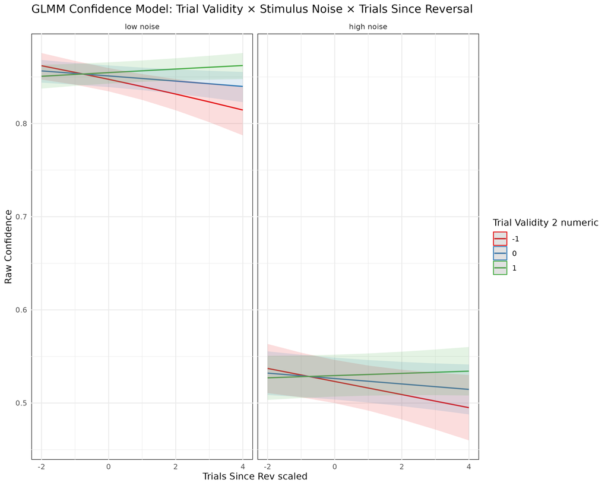

Confidence Model Predictions: Trial Validity × Stimulus Noise × Trials Since Reversal

## Model Comparison

Model Fit Statistics

| Model | AIC | BIC | Log Likelihood | N Observations | N Subjects | Convergence |
| --- | --- | --- | --- | --- | --- | --- |
| Accuracy Model | 28276.04 | 28348.70 | -14129.02 | 23706 | 201 | ✅ \| |
| Choice Model | 24993.29 | 25065.95 | -12487.65 | 23706 | 201 | ✅ \| |
| Response Time Model | 22313.55 | 22401.38 | -11146.77 | 48198 | 201 | ✅ \| |
| Confidence Model | 35522.16 | 35636.34 | -17748.08 | 48198 | 201 | ✅ \| |

## Key Findings Summary

### Main Effects

[output not shown]

## Conclusions

This analysis reveals robust evidence for **predictive processing** in emotion recognition:

1. **Trial validity** consistently affects all dependent measures
2. **Stimulus noise** primarily affects response times and confidence
3. **Learning effects** are evident across all models
4. **Face emotion** shows consistent effects on choice and confidence

The results support the hypothesis that participants use **predictive cues** to guide their responses, with **learning effects** modulating these relationships over time.

*Report generated on 2025-08-06*  
*Analysis: CWT fMRI GLMM Study*